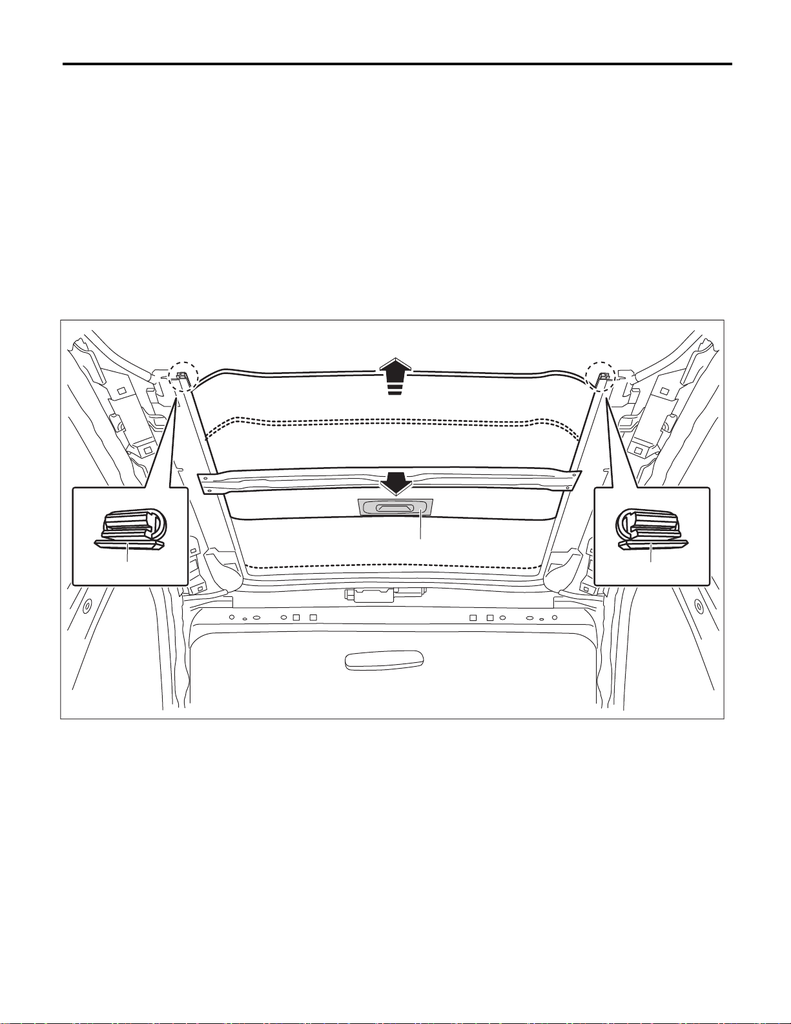

SR-20

Sunshade

SUNROOF/T-TOP/CONVERTIBLE TOP (SUNROOF)

8.Sunshade

A: REMOVAL

1) Disconnect the ground cable from battery. <Ref. to NT-5, BATTERY, NOTE, Note.>

NOTE:

For models other than STI model, disconnect the ground terminal from battery sensor.

2) Remove the lid assembly - sunroof. <Ref. to SR-7, REMOVAL, Glass Lid.>

3) Remove the trim panel - roof assembly. <Ref. to EI-99, REMOVAL, Roof Trim.>

4) Remove the sunshade assembly.

CAUTION:

Be careful not to damage the sunshade assembly.

(1) Attach protective tape (a) on the handle of sunshade assembly.

(2) Remove the left and right stoppers (b).

(3) Remove the sunshade assembly while pulling the center of the brace downward.

B: INSTALLATION

1) Install the sunshade assembly.

2) Install the trim panel - roof assembly. <Ref. to EI-102, INSTALLATION, Roof Trim.>

3) Install the lid assembly - sunroof. <Ref. to SR-7, REMOVAL, Glass Lid.>

4) Connect the battery ground terminal. <Ref. to NT-5, BATTERY, NOTE, Note.>

NOTE:

For models other than STI model, connect the ground terminal to battery sensor.

SR-00206

(a)

(b)

(b)

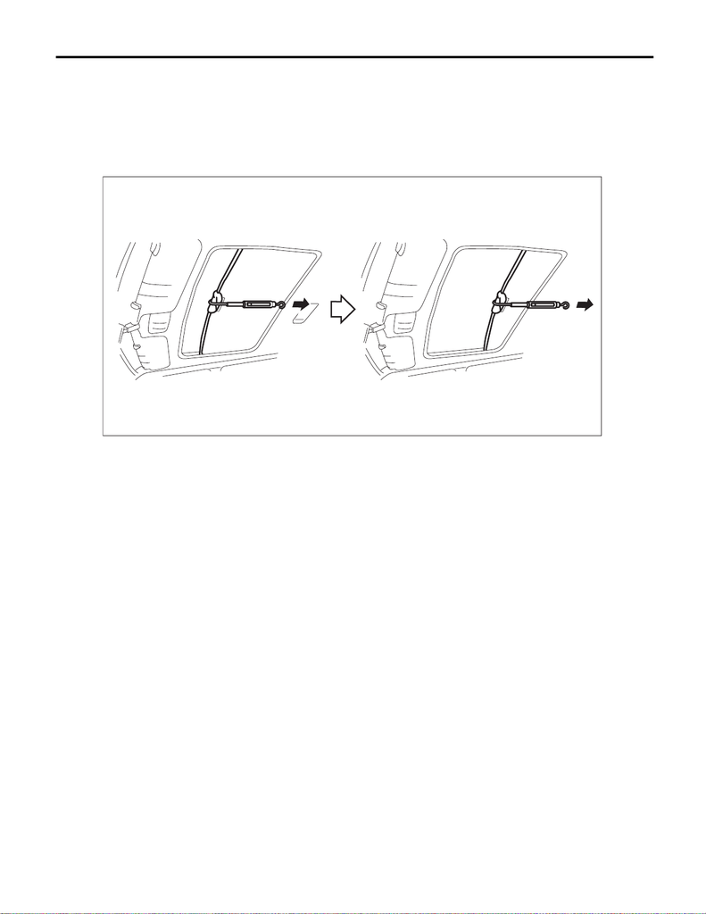

SR-21

Sunshade

SUNROOF/T-TOP/CONVERTIBLE TOP (SUNROOF)

C: INSPECTION

1. MOVING LOAD OF SUNSHADE ASSEMBLY

1) Attach a spring scale together with a cloth to the edge of sunshade assembly.

2) Pull the spring scale to check the moving load of the sunshade assembly.

Moving load of sunshade assembly:

NOTE:

3) If the inspection result exceeds the standard, check that the sunshade assembly or the rail assembly -

sunroof is installed properly. If necessary, replace the sunshade assembly or the rail assembly - sunroof.

SR-00175

[figure not shown]

SR-22

Sunshade

SUNROOF/T-TOP/CONVERTIBLE TOP (SUNROOF)

[figure not shown]

EXTERIOR/INTERIOR TRIM

EI

Page

1. General Description ...................................................................................2

2. Front Under Cover ...................................................................................21

3. Mud Guard ...............................................................................................23

4. Floor Under Protector ...............................................................................25

5. Fuel Tank Protector ..................................................................................26

6. Front Hood Duct .......................................................................................27

7. Front Grille ...............................................................................................28

8. Front Bumper ...........................................................................................30

9. Rear Bumper ............................................................................................41

10. Cowl Panel ...............................................................................................45

11. Roof Molding ............................................................................................48

12. Side Garnish ............................................................................................50

13. Trunk Lid Garnish .....................................................................................51

14. Rear Spoiler .............................................................................................52

15. Heat Shield Cover ....................................................................................54

16. Ornament .................................................................................................55

17. Door Trim .................................................................................................56

18. Instrument Panel Lower Cover .................................................................61

19. Glove Box .................................................................................................63

20. Center Console ........................................................................................66

21. Console Box .............................................................................................67

22. Instrument Panel Assembly .....................................................................69

23. Lower Inner Trim ......................................................................................81

24. Upper Inner Trim ......................................................................................85

25. Rear Quarter Trim ....................................................................................89

26. Rear Shelf Trim ........................................................................................92

27. Trunk Room Trim .....................................................................................95

28. Sun Visor ..................................................................................................97

29. Assist Grip ................................................................................................98

30. Roof Trim .................................................................................................99

31. Floor Mat ................................................................................................105